# Potential Fertility and Motherhood in Hiring Evaluations

Evidence from a factorial survey experiment with supervisors in Chile

Tania Hutt

Department of Sociology, Pontificia Universidad Católica de Chile

Mini Conferencia de Desigualdades, Observatorio de Desigualdades UDP

October 2026

## Motivation

Motherhood in labor market research is often conceptualized as a dichotomy: we compare the evaluations and labor market outcomes of childless women with those of mothers’.

This overlooks a **forward-looking dimension**. Employers do not only assess who a candidate is now; they forecast who she is likely to become.

**Future fertility and family plans:** women may be evaluated not only in relation to their current parental status, but also in relation to how likely it is that they will a have child in the near future.

- Supply side: fertlity expectations shape women’s work and family aspirations (e.g. Bass 2015; Thébaud and Taylor 2021).
- Demand side: employer’s fertility expectations could shape hiring preferences against women who are likely to have a child in the short term (e.g, Becker et al. 2019; Peterson et al. 2022).
  - And unlike current motherhood, it is prospective and unverifiable: a judgment about anticipated rather than observed behaviour, which women cannot easily contest.

## Why the distinction matters theoretically

Distinguishes what is attributable to **current caregiving** from what is attributable to **anticipated childbearing**.

Motherhood stereotypes concern **current performance and costs already incurred**. Potential fertility concerns **assumptions about future behaviour**.

**Anticipatory statistical discrimination**

(Phelps 1972; Aigner and Cain 1977)

Employers forecast the expected costs and risks of anticipated childbearing — leave, disruption, turnover — and attach them to individual women.

→ Penalties on how **costly** and **risky** applicants are perceived to be, regardless of current motherhood status.

**Status-based devaluation**

(Ridgeway and Correll 2004; Correll et al. 2007)

Motherhood operates as a status characteristic: it activates diffuse expectations about professional standing.

→ Penalties on **growth potential** and **competence**, which could be exacerbated with future childbearing.

## Research questions

> What stereotypes do employers associate with the **potential fertility** and **current motherhood status** of women job applicants in Chile?

> Do men experience similar penalties?

## The case of Chile

- Chile has a history of **maternalist policies**: long maternity leave, almost no paternity leave, and childcare provision attached to women employees only.
- Women’s participation in the labor force has stalled in the past decades, currently at 53.7% (Men: 71.3%). Particularly high female unemployment rate of 10.9% (Men: 8.7%).
- Historic (and globally) low fertility rate of 0.99 births per woman.
- Current policy debates around increasing fertility and changing employment policies regarding childbearing (such as universal day care).

## Data

Preregistered factorial survey experiment with 1449 individuals currently employed in supervisory or managerial level jobs in Chile.

Respondents evaluated two applicants for a vacancy presented by a fictional human resources firm (2,898 obs).

Six attributes vary at the profile level:

| Attribute | Levels |
| --- | --- |
| Gender | woman / man |
| Marital status | single / married |
| Parental status | no children / one child / two children |
| Family plans | in 2 years / in 5 years / does not want children |
| Experience | 6 / 7 / 8 years |
| Performance on a technical test | 5.8 / 6.0 / 6.3 |

Potential fertility was signalled by the **family plans** attribute, crossed with parental status. This separates current motherhood from anticipated fertility as distinct experimental factors.

## Design

**Design**

- Vignette-based, rating outcomes
- D-efficient fractional design
- 200 unique profiles, 100 blocks of 2
- Each block assigned to ~14 respondents

**Efficiency**

- D-efficiency = 0.922
- G-efficiency = 0.925
- 28 model parameters, all identifiable

**Presentation order and wording template are within-subject and fully crossed**. Both are controlled in all models.

Design, hypotheses and analysis plan preregistered at AsPredicted #297542 prior to data collection.

## Between- and within-subject structure

**Type of occupation is between-subjects.** Each respondent evaluated profiles of either professional or technical applicants only.

- Professional arm: financial associate, degree in business engineering
- Technical arm: accounting analyst, technical qualification in accounting
- Moderation tests find no evidence that occupational level conditions the main effects.

**Results presented here are from the pooled sample.**

## La tarea que los participantes vieron

#### POSTULANTE A

#### Antecedentes profesionales

- Marcela cuenta con 7 años de experiencia laboral continua en el ámbito de la contabilidad y las finanzas.
- Posee Título profesional en Ingeniería Comercial y actualmente trabaja como Asociada financiera.

#### Trayectoria laboral

A lo largo de su trayectoria profesional, se ha desempeñado tanto en el sector público como en el privado, participando en actividades relacionadas con el seguimiento de información financiera, la elaboración de reportes y la participación en procesos de planificación. En sus cargos anteriores, Marcela asumió responsabilidades de complejidad creciente, incluyendo el manejo de información financiera diversa, la comunicación con distintas áreas de la organización y el apoyo a equipos de trabajo.

#### Notas del entrevistador

- Indicó que valora el orden de los procesos internos de la empresa y la posibilidad de continuidad dentro de la organización.
- En el ámbito personal, Marcela se encuentra casada, tiene un hijo y le gustaría tener otro en 2 años más.
- Marcela expresó su interés en integrarse a una organización de gran tamaño, con proyección que le permita continuar desarrollándose laboralmente.

#### Desempeño en test de habilidades técnicas

La nota necesaria para aprobar era un 5.0 y Marcela aprobó con 6.0.

El texto destacado marca los atributos manipulados. Todo lo demás se mantuvo constante entre perfiles. Se usaron dos redacciones de este template, cruzadas con el orden de presentación.

## Outcomes

**Evaluation**

Hiring recommendation

Good investment

**Competence index**

- Capable
- Trustworthy

· $\alpha = .76$

**Growth index**

- Promising
- Ambitious
- Take on new challenges
- Be promoted

· $\alpha = .84$

**Cost**

- Operationally costly
- Requests accommodations
- Uses company benefits

$\alpha = .51$ — below threshold, analysed as separate items

**Risk**

**Risk index**

- Committed long-term (reversed)
- Late or absent
- Resign
- Risky for continuity

· $\alpha = .71$

**Preregistered rule.** Items aggregate into indices where Cronbach’s $\alpha \geq .70$; otherwise they are analysed individually.

## Estimation

**OLS with cluster-robust standard errors (CR2), clustered by respondent.**

Models pool the two occupational conditions, with occupational level as a control.

Results reported as **marginal means and contrasts** rather than coefficients (Leeper, Hobolt and Tilley 2020).

Whether a penalty is **gendered** is tested as a difference-in-differences.

## How results are reported

Each figure shows the same four blocks of contrasts, for each outcome:

| Block | Comparison |
| --- | --- |
| **Gender, no family** | Women vs. men, among childless applicants stating no plans - “pure” gender penalty |
| **Imminent fertility, childless** | Childbearing plans in 2 years vs. no plans — women, men, difference - future motherhood penalty |
| **Imminent fertility, parents** | Childbearing plans in 2 years vs. no further plans — women, men, difference - additional child penalty |
| **Parenthood, no fertility plans** | Two children vs. none — women, men, difference - “pure” motherhood penalty |

Filled points represent statistical significance (Benjamini-Hochberg adjustment).

## Two contrasts not shown in the figures

To ease readibility of the figures, I will not present two contrast that are null for almost all outcomes.

**A five-year horizon carries no penalty** on any outcome, with a single exception on long-term commitment.

**One child carries no penalty.** Overall, no evidence of penalties for “one child and done”, except for the perception that the applicant will request accommodations.

> I will return to these findings in the discussion.

## # Evaluations of the applicant

## Hiring recommendation

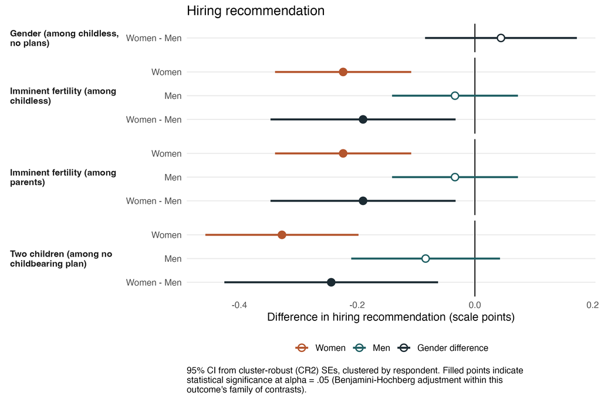

## Competence index

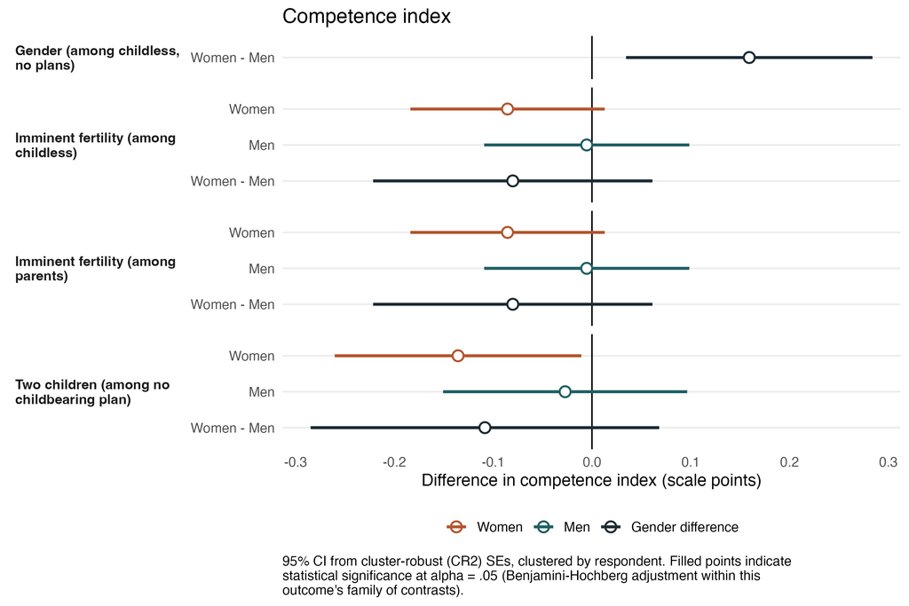

## Growth index

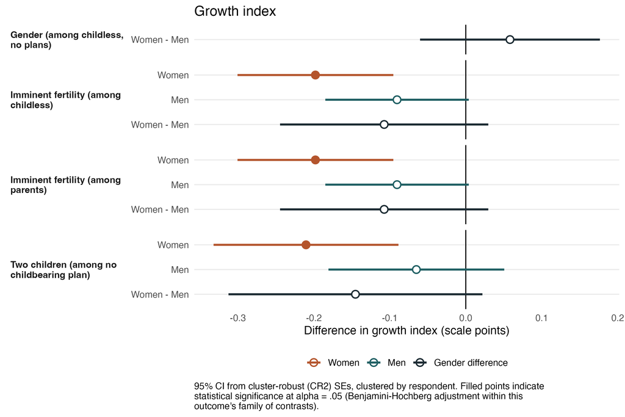

# Prospective behavior

## Operational cost

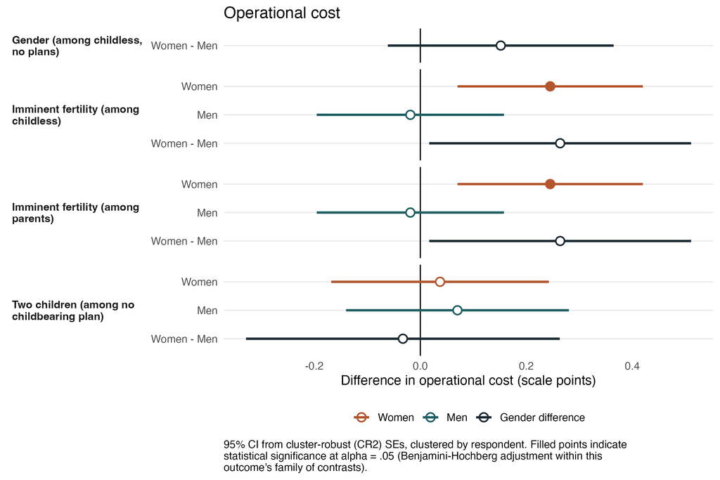

## Requests for accommodations

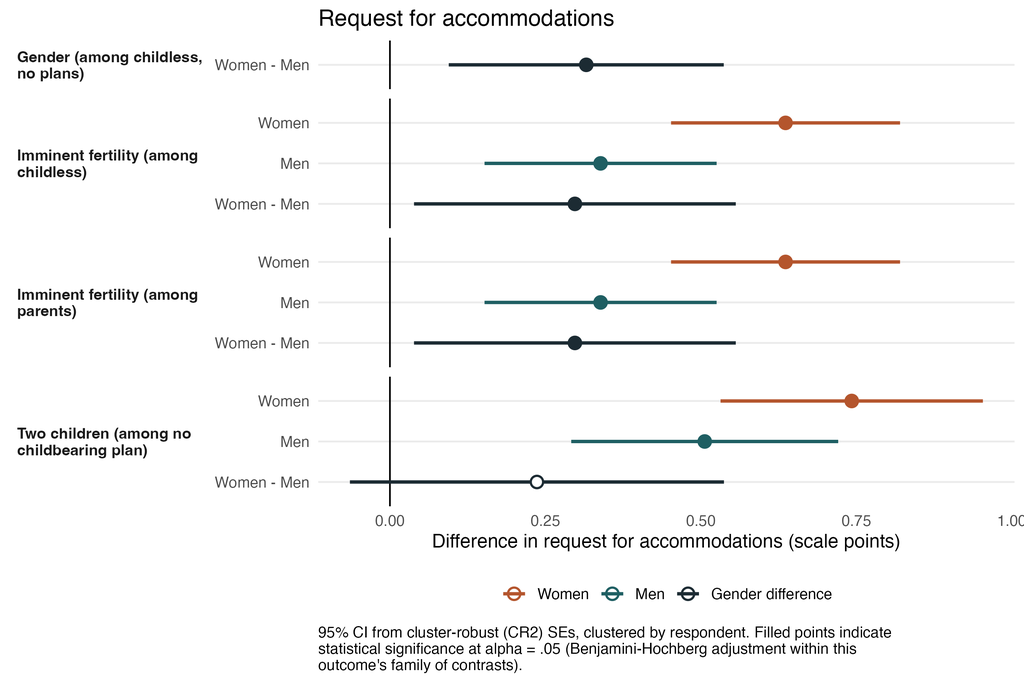

## Risk index

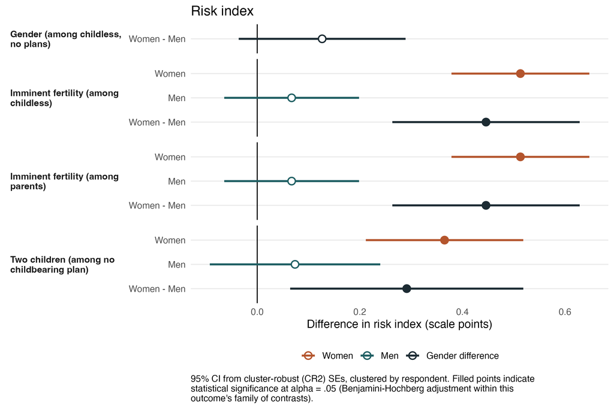

## Summary

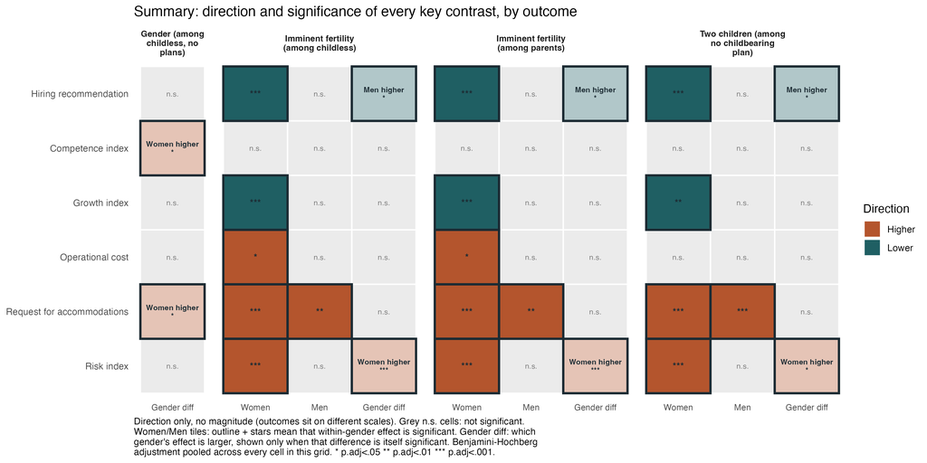

Direction only, not magnitude — outcomes sit on different scales.

# Discussion

## Conclusions I — three penalties, three patterns

**Gender alone**

**Anticipated fertility**

Penalises childless women and mothers **alike**, and reaches every outcome except perceived competence.

Concerns activate **only when fertility is imminent** — no clear penalties for longer-term plans (5 years).

**Current motherhood**

Penalised **only at the second child**. No evidence that “one and done” mothers are penalised.

A notable finding in a context of rising one-child families in Chile.

The penalty attaches to the anticipated birth, not to the applicant’s current status.

## Conclusions II — what separates the two mechanisms

**Operational cost**

Motherhood does **not** raise perceived operational cost; imminent fertility does.

→ The concern focuses around **pregnancy and maternity leave**, not ongoing caregiving.

**Competence**

Evaluators do **not** judge these applicants as less capable or less trustworthy — not what a status-based account of the motherhood penalty predicts (Correll, Benard and Paik 2007).

→ The explanation shifts from inferences about **ability** toward normative expectations about **who absorbs the costs of care** — in Chile today, gender stereotypes appear to operate through other perceptions, not through competence itself.

In the Chilean case, those expectations are reinforced by a family policy regime that attaches leave and benefits primarily to mothers.

## Conclusions III — where the asymmetry lies

Family signals raise the expected use of accommodations for **both women and men**.

But the negative associations that follow from those accommodations are placed **solely on women** — being costlier, having less growth potential, and being riskier.

## Work in progress! Next steps:

- Attention-check sensitivity analysis: full vs. restricted sample
- Additional robustness tests: response time, time in task, etc.
- Moderation by evaluator characteristics: gender, parental status, industry, job level, workplace-norm attitudes
- Interactions with applicants’ marital status and achievement test

**Thank you!**

tania.hutt@uc.cl

## Appendix: good investment

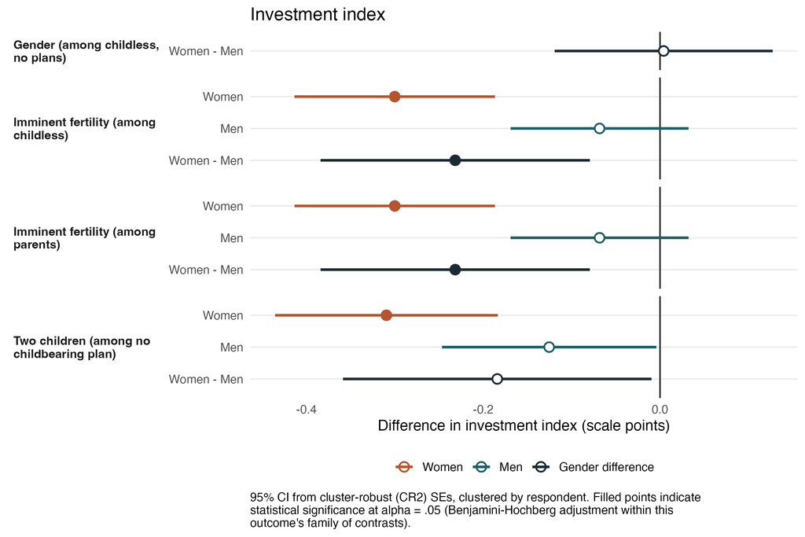

## Appendix: use of company benefits

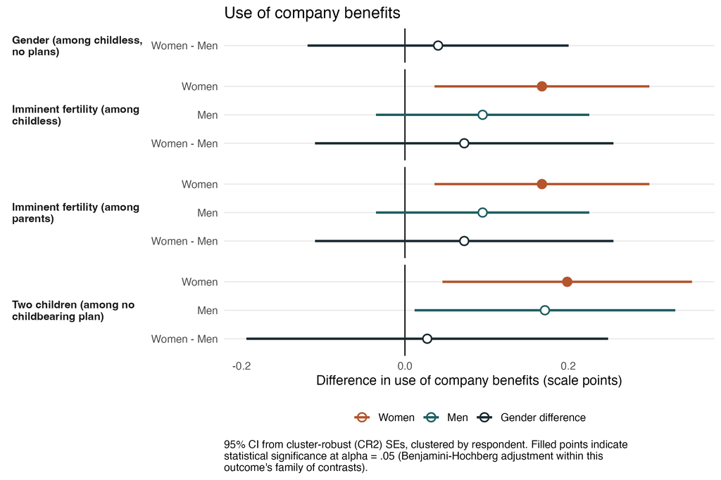

## Appendix: does occupational level moderate the penalties?

Preregistered moderation tests find no evidence that occupational level conditions the focal effects.

- Gender × occupation: no coefficient exceeds $|0.052|$ across outcomes
- Confidence bounds exclude moderation greater than **0.14 scale points**
- Heterogeneity across arms: Cochran $Q = 306.2$, $df = 285$, $p = .185$

Pooling reduces standard errors by **29%**.

## Appendix: response distributions

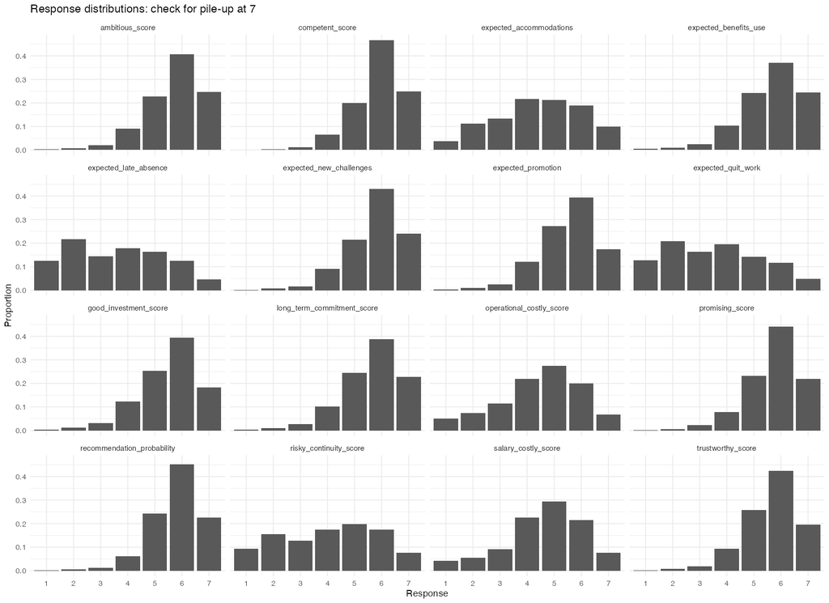

## Appendix: model sets

| Set | Specification | Used for |
| --- | --- | --- |
| SET 2a | Gender × Parental status | Motherhood contrasts |
| SET 2b | Gender × Family plans | Imminent fertility contrasts |
| Combined | Both two-way interactions | Gender contrast at no children, no plans |
| SET 5a–5e | Occupational level interactions | Appendix moderation |

## All sets control for marital status, experience, test performance, occupational level, presentation order and template version. Estimated on the pooled sample with cluster-robust (CR2) standard errors.

## References

Aigner, D. J., and G. G. Cain. 1977. “Statistical Theories of Discrimination in Labor Markets.” *Industrial and Labor Relations Review* 30(2): 175–187.

Auspurg, K., and T. Hinz. 2015. *Factorial Survey Experiments*. Thousand Oaks, CA: SAGE.

Bond, T. N., and K. Lang. 2019. “The Sad Truth about Happiness Scales.” *Journal of Political Economy* 127(4): 1629–1640.

Correll, S. J., S. Benard, and I. Paik. 2007. “Getting a Job: Is There a Motherhood Penalty?” *American Journal of Sociology* 112(5): 1297–1338.

Hainmueller, J., D. J. Hopkins, and T. Yamamoto. 2014. “Causal Inference in Conjoint Analysis: Understanding Multidimensional Choices via Stated Preference Experiments.” *Political Analysis* 22(1): 1–30.

Leeper, T. J., S. B. Hobolt, and J. Tilley. 2020. “Measuring Subgroup Preferences in Conjoint Experiments.” *Political Analysis* 28(2): 207–221.

Liddell, T. M., and J. K. Kruschke. 2018. “Analyzing Ordinal Data with Metric Models: What Could Possibly Go Wrong?” *Journal of Experimental Social Psychology* 79: 328–348.

Phelps, E. S. 1972. “The Statistical Theory of Racism and Sexism.” *American Economic Review* 62(4): 659–661.

Pustejovsky, J. E., and E. Tipton. 2018. “Small-Sample Methods for Cluster-Robust Variance Estimation and Hypothesis Testing in Fixed Effects Models.” *Journal of Business & Economic Statistics* 36(4): 672–683.

Ridgeway, C. L., and S. J. Correll. 2004. “Motherhood as a Status Characteristic.” *Journal of Social Issues* 60(4): 683–700.